# Parcial Final Estadistica Bayesiana

Jhonatan Smith Garcia - Alexis Nieto Morales c.c 1035879811 - c.c 1010088521

Agosto, 2021

## Resumen

La aproximacion de la estadistica clasica a la hora de entender un problema de regresion lineal es un enfoque netamente cuantitativo y dependiente de la toma adecua de datos. Si por algun motivo; dicho muestreo y diseño de experimento para la recolecta de informacion llegase a tener algun inconveniente; el sesgo de los datos a la hora de ajustar el modelo puede llevar a inferencias erroneas.

Claro, siempre y cuando los datos sean confiables, no habria problema con el enfoque clasico.

Sin embargo, una de las fortalezas de la estadistica Bayesiana consiste en la implicacion de los denominados “expertos” para adquirir informacion respecto a el problema en aprticular, ayudandose asi, de el criterio de dichos sujetos para la recolecta de informacion donde; el margen de error dependerá del conocimiento final del experto respecto al problema a tratar.

Suponiendo que la persona a entrevistar (experto) suministra informacion confiable respecto al campo de investigacion a tratar; el modelo final estimado mediante un enfoque Bayesiano cumple la misma funcion que el modelo con un enfoque clasico; sin embargo, con el valor agregado (y nuevamente, suponiendo que el proceso se realiza correctamente) de agilizar el proceso de recoleccion de datos y disminuir los costos de la investigacion.

Si se plantea realizar una estimacion para un modelo de regresion simple para un vechiculo motorizado, en un enfoque clasico, se deberia de tener una cantidad de informacion sustancial, que haya sido correctamente recolectada y ademas, realizar un analisis exhaustivo de las tecnicas a utilizar, analisis de supuestos y demas.

Para responder esta pregunta desde la estadistica Bayesiana, en esfuerzo no irá enfocado en el como recolectar los datos y obtener una muestra representativa de la poblacion problema a analizar; si no mas bien en identificar y analizar al experto mas optimo a tener en cuenta; filtrar entre todos los candidatos posibles de seleccion, realizar un analissi exhaustivo de su experiencia en el campo de interes, cersiorarse de realizar un optimo proceso de elicitacion para evitar caer en sesgos y finalmente, realziar un proceso de simulacion.

En el mercado de segunda mano, ¿ Cual es el precio de una motocicleta tipo Boxer?

# Seleccion del vehiculo.

El vehiculo de estudio seleccionado fue la motocicleta tipo Boxer. Las personas encargadas de llevar a cabo la investigacion del proceso se encuentran en municipios donde e dificulta el acceso a concesionarios y demás lugares para realizar un adecuo estudio para la seleccion de un experto.

En un principio, se desea analizar el precio de compra-venta de vehiculos automotrices pero; dadas las circunstancias, es de dificil acceso dicha informacion. Por tanto, se opta finalmente realizar dicho analisis en vehiculos motorizados.

Cabe destacar que el municipio donde se realizará la elicitacion es Puerto Berrio Antioquia. En dicha localidad, el vehiculo usado es, acorde a todos los expertos entrevistados en un proceso de seleccion; la moto Boxer.

# Seleccion del experto.

En el proceso de elicitacion estadistica, como ya se mencionó anteriormente; la seleccion del experto es crucial para llevar a cabo una correcta elicitacion.

Debido a que el analisis central de toda la informacion, las posibles inferencias a realizar y todos los calculos a estimar, van a girar en torno a las estimaciones del experto; una incorrecta seleccion del mismo puede verse penalizada en ultimas con estimaciones muy pobres.

Por otra parte, una correcta seleccion del experto permitirá la obtencion de una buena aproximacion a la solucion real del problema.

# Criterios de seleccion del experto.

Como se espera trabajar en la estimacion del precio de motocicletas Boxer de segunda mano, el experto debe cumplir con los siguientes criterios:

- Años de experiencia: El experto ha de contar con minimo 5 años de experiencia para asegurar que conoce el mercado. Se escoge este valor pues, se asume que alguien que lleva trabajando 5 años en la compra-venta de vehiculos ha de conocer bien el mercado y los precios que utiliza.
- Experiencia en ventas: Otro de los criterios fundamentales para entender el problema de una manera adecuada es la experiencia en ventas. Si por algun motivo el experto no ha realizado ventas de segunda mano de estos vehiculos, dificilmente podria dar una buena estimacion del precio a tener en cuenta.
- Conocimiento del vehiculo: El experto, entre otras cosas, ha de conocer el vehiculo, cuales son los mejores valorados y por qué. Sus fincionalidades, su utilidad, su vida media, etc. Verificar que el experto conozca estas especificaciones es vital para asegurar que dará una buena estimacion.
- Estudios previos/ Experiencia laboral: Si el experto tiene estudios en el campo o ha trabajado en el campo de interes, es informacion que ayudaria a mejorar la precision de la estimacion. En este caso; si el experto ha trabajado en la compra-venta de motos Boxer o en un taller automotriz, son criterior que ayudarán.

Si el experto seleccionado cumple con la totalidad de estos criterios; se dice que es un experto optimo para elicitar el precio promedio de venta de vehiculos Boxer de segunda mano.

# Experto seleccionado:

El experto seleccionado es Brayan Correa Zapata. Trabaja como mecanico automotriz en un taller en el municipio de Puerto Berrio desde el año 2015 (cerca de 6 años de experiencia).

Inicialmente al terminar sus estudios secundarios decide comenzar una tecnica de reparacion de vehiculos para luego ser contratado en un local de reparacion de vehiculos.

Inicialmente comienza trabajando como mecanico donde en esencia se dedicaba a reparar vehiculos pero, con el paso del tiempo, empezó a incursionar en la compra de vehiculos motorizados de segunda mano para realizarles reparaciones, recuperaciones y posterior venta. (Esto es, 6 meses despues de haber comenzado a laborar en el local)

Esto es lo que ha realizado durante los ultimos 6 años de su vida, se ha independizado y genera ingresos estables y constantes gracias a la compra y venta de vehiculos.

Su metodo de venta está apalancado en las redes sociales. En general, al ser un municipio relativamente pequeño y ser pionero en el mercado de segunda mano; es reconocido en sus redes sociales donde tiene un perfil muy activo, publicando constantemente los vehiculos en venta y gracias a este mismo medio, realiza la misma compra-venta de vehiculos.

Hablando con el experto, afirma que la moto mas comercial en el municipio de Puerto Berrio es la moto Boxer. Describe que es un vehiculo con una excelente adaptabilidad a la zona ruraly urbana, teniendo en cuenta que es un municipio con muchas zonas rurales y de dificl acceso.

# Moto Bóxer CT 100

Antes de iniciar la especificación de las características de este vehículo, pasemos un poco a través de la historia de esta moto en Colombia y siguiendo el camino durante el tiempo hasta encontrarnos con sus características que la hacen distinguir de las demás. La marca llega a Colombia de la mano de AUTECO también en la década de los 90, cuando se establecen los primeros contactos con Bajaj para la distribución y comercialización de las motocicletas de la marca al interior del país. Esta mención es, pues, Boxer pertenece a Bajaj, la empresa fabricante de vehículos de 2 y 3 ruedas más importante de la India y la cuarta a nivel global, que con más de 70 años de existencia se ha ganado a pulso su lugar en la industria.

La anterior mención sobre los creadores de este vehículo no es más sino expresar el gran contenido en experiencia y conocimiento de sus productores acumulados durante muchos años y reflejadas en este facilitador de transporte. Si bien Boxer llegó junto a otros modelos de Bajaj como la Pulsar 180 y la Kawasaki KMX 125, la referencia CT-100 se convirtió rápidamente en todo un éxito de ventas entre la clase trabajadora del país, al punto de que hoy en día dicha referencia se sigue comercializando y es reconocida como la moto más vendida en la historia de Colombia. Hoy en día es muy fácil observarlas en cualquier territorio, pues sus ventajas en economía, funcionalidad y adaptabilidad a los distintos terrenos la han convertido en un amigo de las carreteras y veredas para muchos colombianos, no solo a la hora de transitar para cumplir un desplazamiento entre origen y destino, sino también como fuente de ayudad de trabajo para muchas personas. Como dato, tenemos que Bajaj Boxer CT fue la moto más vendida en Colombia en 2019 con 48.160 unidades (15% del mercado nacional), información que ayuda a fundamentar el título ya mencionado sobre esta moto, de ser la más vendida en la historia de Colombia.

Esta motocicleta goza de una configuración básica de fácil mantenimiento y con asombroso rendimiento de combustible. Las cualidades que reúne Boxer en cada una de sus referencias de motos, son difíciles de encontrar por un precio tan económico en otras opciones similares disponibles en el mercado. Esto, representa una ventaja competitiva que los trabajadores y usuarios colombianos del vehículo han sabido apreciar notablemente y por eso existe una preferencia por esta marca cuando se busca una moto con un excelente rendimiento y duración. De aquí que hallamos elegido este vehículo para nuestro estudio.

El Grupo UMA es el distribuidor maestro en Colombia de los vehículos Bajaj, una vez más, empresa productora de la moto escogida para este estudio. Cuenta con una red de más de 500 Centros de Servicio en toda la región, con técnicos Bajaj especializados y certificados para muestra de garantizar accesibilidad también a servicios y cuidado de los vehículos de forma fácil.

# Ficha tecnica

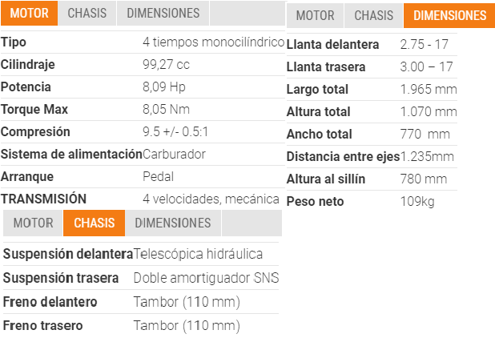

Un punto de venta importante para cualquier motocicleta básica es el consumo de combustible. La Bajaj Boxer CT 100 posee una velocidad máxima de 90 kilómetros por hora y un rendimiento de combustible muy alto, que es más que suficiente para una motocicleta de tal capacidad. También ofrece una economía de combustible de 70 kilómetros por litro en condiciones urbanas y en carretera, dará un kilometraje adicional de 10 a 20 kilómetros por litro.

La calidad de conducción de la Bajaj CT 100 es muy buena, ya que tiene un manillar ligero y un asiento largo, lo que ayuda a obtener buena comodidad a la hora de conducir. Trae un neumático más ancho de 3 pulgadas, el más grande del segmento. La moto ofrece un buen agarre en carretera sobre en terrenos duros, garantizando la máxima seguridad.

En términos generales es una gran opción para las personas que utilizan la moto como medio de trabajo, para estudiantes y personas que quieran tener un gasto mínimo en combustible.

A continuación, mostramos algunas especificaciones de su economía, por ejemplo, a la hora de buscar repuestos para comprar, entre otras opciones. Cabe resaltar que los siguientes, son precios que establecemos como aproximados porque estos pueden variar dependiendo de la ciudad y del distribuidor:

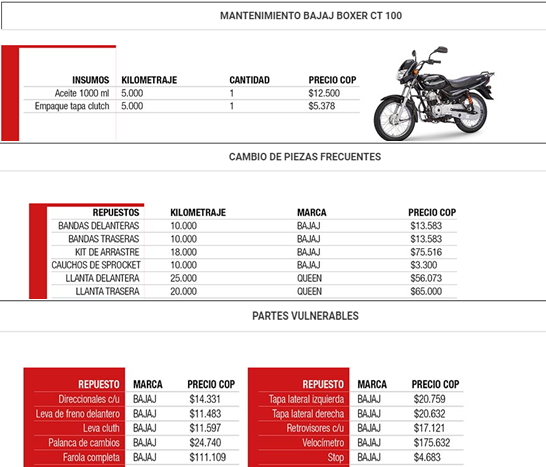

[figure not shown]

# Ejemplificacion del proceso de elicitacion:

- Elicitador: Buenas tardes, señor@ X. ¿ Como se encuentra?
- Experto: Excelente.
- Elicitador: El dia de hoy estaremos trabajando en un proceso de elicitacion estadistica. Le haré unas preguntas muy sencillas y usted solo tiene que responderlas. Si en algun momento no logra comprender algo, le pido por favor que me lo haga saber y buscaré la forma de replantear la pregunta.
- Experto: Ok. Pero, ¿Preguntas acerca de que?
- Elicitador: De hecho, son bastante simples. Son acerca de un tema que usted conoce y entiende muy bien. vamos a hablar acerca de motocicletas, en particular; vehiculos Boxer.
- Experto: Oh, entiendo.
- Elicitador: Primero, hableme de usted un poco, de su experiencia, de como aprendió del tema, hace cuanto trabaja, de todo un poco.
- Experto: Bueno pues yo trabajo…

En este punto de la entrevista se busca constatar que el experto tenga dominio en los temas que se van a tratar y que, con esta informacion; se verifique que en efecto, sea un “experto” en el tema de interes. Para este caso, se busca que sea alguien que conozca mucho acerca de las motocicletas Boxer, por tanto; alguien que las haya comercializado, reparado y vendido, como es este el caso; seria un experto optimo.

- Elicitador: Excelenete, veo que usted conoce muy bien el tema.
- Experto: Si, claro, llevo mucho tiempo trabajando en Y.
- Elicitador: Ahora, dejeme hacerle una pregunta. Si yo le dijiese a usted que existen 100 motos Boxer en este momento, en frente suyo; todas mas o menos iguales, en cuanto a uso, en cuanto a desgaste y digamos, que tienen un desgaste “normal”. Aclarando, por supuesto que son motos de segunda mano. ¿ Cual creeria usted que es el criterio mas importante que influye en el precio de la motocicleta?
- Experto: Pues yo diria que el modelo, es decir; el año que esta moto tiene. DE esas 100 motos, para yo saber el precio, digamos que tendria que fijarme en el kilometraje y el año principalmente.
- Elicitador: perfecto, ahora, si yo le digo que todas esas 100 motos son del año 2019… ¿Cuantas cree que valdrian digamos uno o dos millones de pesos?
- Experto: ¿De las 100?
- Elicitador: Si, de las 100, cuantas estan en ese rango de precio.
- Experto: No pues a ver, teniendo en cuenta lo que le dije, unas 15 motos… Depronto unas 20 si mucho.
- Elicitador: Y cuantas de esas valen digamos, mas de 5 millones?
- Experto: No, eso es mucho para una moto Boxer de segunda, de ese año, imposible. De esas 100, ninguna. Si acaso pues, una.

Se continua haciendo este proceso para dictaminar los valores a elicitar. Llegando a concluir las siguientes tablas:

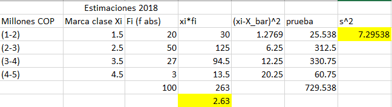

La anterior tabla muestra los datos obtenidos luego de estimar los parametros con ayuda del experto. Los valores dados son para elicitar la media y desviacion tipica del precio estimado para la moto Boxer modelo 2018.

La tabla de datos empieza dando rangos de precio entre 1 y 2 millones de pesos, simulando un valor maximo de 5. Esta cota superior fue asignada puesto que; una moto boxer de 100 CC nueva, como precio maximo esta alrededor de 5 (segun el experto). Se acota a 5. Los datos de interes se encuentran subrayados.

La *media*, es de 2.63; esto se traduce como; segun el experto y los datos suministrados, una moto Boxer modelo 2018 cuesta aproximadamente 2’630.000 COP.

La *varianza* de estos datos es de 7.29538

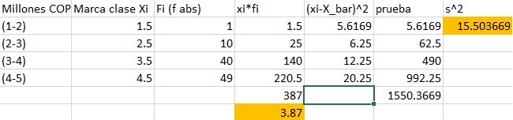

Finalmente, se elicita un segundo punto con ayuda del experto. Analogamente se tiene que:

La *varianza* de estos datos es de 15.503669

Esta informacion es consistente pues, un vehiculo mas reciente debe de ser mas costoso.

*Elicitador: bueno señor@ X, muchas gracias por su colaboracion. Con esto hemos finalizado el proceso. Le agradezco su tiempo y dedicacion* Experto: No, fue con gusto. Feliz dia.

# Estimacion de parametros

Mediante un proceso de simulacion se tiene que:

```r
mu1 = 2.7 # Para moto boxer primer año seleccionado (2018)
sigma1 = 8.1665 # Sigma moto boxer 2018

mu2 = 3.8  # Moto segundo año seleccionado (2020)
sigma2 =  15.754 # Sigma segundo año seleccionado (2020)
```

```r
set.seed(2021)

moto_2018 = (rnorm(1000*20,mu1,sqrt(sigma1))) # Una muestra simulada de 1000
#datos a partir de la info elicitada experto moto 1

moto_2020 = (rnorm(1000*20,mu2,sqrt(sigma2))) # Muestra simulada 1000x20 datos
#de moto 2020

matriz_2018 = matrix(moto_2018, ncol = 20)
matriz_2020 = matrix(moto_2020, ncol = 20)
datos =  cbind(matriz_2018,matriz_2020)
```

Se decide estimar tamaños muestrales iguales a 20 debido a que el experto demuestra conocimiento en el tema y su nivel de confianza en los datos es elevado.

Esta funcion permitirá facilitar los calculos de los parametros a elicitar.

```r
parametros = function(y){
  x = c(rep(18,20),(rep(20,20))) #Valores 18 y 20 representan el año
  res = as.vector(summary(MCMCregress(y~x))$statistics[,1])
  return(res)
}
```

```r
coste = matrix(prueba2, ncol = 3) # Matriz donde se guardan los 3 vectores
# claves; B0,B1, siigma2
```

[output not shown]

Esta ultima matriz posee los paramtetros de interes. De esta, se calcularán los parametros de la distribucion Apriori.

# $(\beta_0 , \beta_1)'$

Hasta aca, se tiene matriz con las 3 columnas de abajo.

*Media $\beta_0$*

```r
b0 = colMeans(coste[,-3])
b0
```

```
## [1] 2.458959 2.197403
```

*Precision $\beta_0$*

```r
B0 = solve(var(coste[,-3]))
B0
```

```
##             [,1]        [,2]
## [1,] 0.010902173 0.003369171
## [2,] 0.003369171 0.010825037
```

Estos serán los parametros para la normal Multivariable.

```r
 m<-mean(coste[,3])
v<-var(coste[,3])
# Estos son los parametros de la gamma inversa
 (alfa<-m^2/v+2)
```

```
## [1] 2.044317
```

```r
(beta<-m*(m^2/v+1))
```

```
## [1] 2.281112
```

Y estos serán los parametros de la gamma inversa.

Ahora, se define esta funcion para calcular probabilidades de la funcion gama inversa; donde a y b son alfa y beta respectivamente.

```r
invGamma <- function(a, b, x){
    k <- (b**a)/gamma(a)
    w <- x**(-a-1)
    v <- exp(-b/x)
    k*w*v
}
```

```r
b0
```

```
## [1] 2.458959 2.197403
```

# Datos muestreados OLX

```r
muestreo = read.csv2(file.choose(),sep="")
```

```r
muestreo$ID<- NULL
attach(muestreo)
```

# Muestras OLX

Sin embargo, se deben trabajar con modelos BOXER 2020 y 2018.

```r
muestra_18_20 = muestreo[muestreo$modelo==c(18,20),]
modelo = muestra_18_20$modelo

precio = (muestra_18_20$precio)*(1/1000000)
```

```r
muestra_olx = data.frame(precio,modelo)
```

```r
summary(muestra_olx)
```

```
##      precio          modelo
##  Min.   :2.600   Min.   :18.00
##  1st Qu.:3.550   1st Qu.:20.00
##  Median :3.700   Median :20.00
##  Mean   :3.635   Mean   :19.64
##  3rd Qu.:4.000   3rd Qu.:20.00
##  Max.   :4.200   Max.   :20.00
```

# Muestras mercadolibre

Estos datos fueron obtenidos al observar una serie de publicaciones de motocicletas de segunda mano BOXER CT 100 en oferta.

```r
precios_2018=c(3650000,3800000,3800000,3800000,3400000,3100000,2800000)
precios_2018=precios_2018/1000000

precio_2020=
c(3900000,4250000,3400000,3650000,4000000,4500000,3800000,4400000,3700000,4350000,4120000,4000000)
precio_2020=precio_2020/1000000
```

```r
año_18 = c(18,18,18,18,18,18,18)
año_20 = c(replicate(12,20))
```

```r
precio = c(precios_2018,precio_2020)
modelo = c(año_18, año_20)
```

```r
datos1 = data.frame(precio,modelo)
```

Uniendo las dos muestras…

```r
muestreo_datos = rbind(muestra_olx,datos1)
summary(muestreo_datos)
```

```
##      precio          modelo
##  Min.   :2.600   Min.   :18.0
##  1st Qu.:3.600   1st Qu.:18.0
##  Median :3.800   Median :20.0
##  Mean   :3.747   Mean   :19.4
##  3rd Qu.:4.000   3rd Qu.:20.0
##  Max.   :4.500   Max.   :20.0
```

```r
attach(muestreo_datos)
```

En esta base de datos muestreada, los valores de la variable año se identifican con sus dos ultimos digitos. Asi, por ejemplo; 2020= 20, 2018=18, etc.

Ademas, se decide muestrear los valores reales a partir de anuncios de las paginas web OLX y mercadolibre pues allí se puede encontrar los valores reales para motos de las caracteristicas solicitadas en oferta.

La seleccion para la pagina de OLX se hizo de manera automatica con la base de datos adjuntada.

Para MercadoLibre se hizo de manualmente pues el sitio web no permitida aplicar el algoritmo de extraccion de datos.

Finalmente, la base de datos sobre la cual se hará aplicará el modelo con los parametros estimados corresponde a vehiculos motorizados BOXER CT 100 especificamente de modelos 2018 y 2020.

# Modelo final

Sobre los datos, se aplica un primer modelo de RLS.

```r
modelo_regresion = lm(muestreo_datos$precio~muestreo_datos$modelo)

summary(modelo_regresion)
```

```
##
## Call:
## lm(formula = muestreo_datos$precio ~ muestreo_datos$modelo)
##
## Residuals:
##      Min       1Q   Median       3Q      Max
## -0.69333 -0.27893  0.05857  0.29607  0.55857
##
## Coefficients:
##                       Estimate Std. Error t value Pr(>|t|)
## (Intercept)           -2.53952    1.45204  -1.749  0.09126 .
## muestreo_datos$modelo  0.32405    0.07476   4.334  0.00017 ***
## ---
## Signif. codes:  0 '***' 0.001 '**' 0.01 '*' 0.05 '.' 0.1 ' ' 1
##
## Residual standard error: 0.3753 on 28 degrees of freedom
## Multiple R-squared:  0.4015, Adjusted R-squared:  0.3802
## F-statistic: 18.79 on 1 and 28 DF,  p-value: 0.0001705
```

Aqui se observan los parametros del modelo.

Se escoge la matriz de precision a calcular. (el B0 anterior presentaba problemas, asi que se digita manualmente)

```r
B01 = c(0.010902173, 0.003369171,0.010902173, 0.003369171)
B01 = c(0.010902173, 0.003369171, 0.003369171, 0.010902173)
B02 = matrix(B01, ncol = 2)
```

Se utiliza MCMCpack para ajustar el modelo final y se obtiene que:

```r
modelo_final = MCMCregress(modelo_regresion,muestreo,b0 = b0,B0 = B02,c0 = alfa, d0 = beta)
```

```r
summary(modelo_final)
```

```
##
## Iterations = 1001:11000
## Thinning interval = 1
## Number of chains = 1
## Sample size per chain = 10000
##
## 1. Empirical mean and standard deviation for each variable,
##    plus standard error of the mean:
##
##                          Mean      SD  Naive SE Time-series SE
## (Intercept)           -2.3298 1.79518 0.0179518       0.017604
## muestreo_datos$modelo  0.3132 0.09246 0.0009246       0.000906
## sigma2                 0.2224 0.06197 0.0006197       0.000667
##
## 2. Quantiles for each variable:
##
##                          2.5%     25%     50%     75%  97.5%
## (Intercept)           -5.8179 -3.4970 -2.3232 -1.1675 1.2466
## muestreo_datos$modelo  0.1275  0.2540  0.3128  0.3738 0.4935
## sigma2                 0.1325  0.1785  0.2121  0.2546 0.3694
```

De la tabla anterioir, se tienen los valores para el modelos de regresion lineal, donde:

(Intercept) = -2.3298 pendiente = 0.3132 sigma2 = 0.2224

Finalmente, este es el modelo calculado via simulacion, ayudado de la estimacion del experto y datos sustraidos de la muestra con valores reales.

Con esto, el modelo estima los valores para una moto BOXER CT 100 donde se ingresa en la variable x, el precio año escalado para dar como resultado el precio Y escalado.

- En particular si X = 20; el precio estimado del modelo es de 3.9342
- Para X = 18; el valor del precio estimado del modelo es 3.3078

Acorde con la informacion otorgada por el experto, la media del precio de una moto BOXER es de 2.63 millones para una moto del 2018 y 3.87 para una del 2020.

# Comparando errores del modelo ajustado via simulacion vs valores experto

```r
# Error cometido 2018

(3.3078-2.63)/3.3078 # Error porcentual cometido segun el modelo
```

```
## [1] 0.2049096
```

```r
# Error cometido 2020

(3.9342-3.87)/3.9342 # Error porcentual cometido segun modelo
```

```
## [1] 0.01631844
```

Al observar los datos calculados anteriormente, se percibe un error relativo mayor para la estimacion del precio a una moto del 2018. Esto puede indicar que el conocimiento del experto en dicho punto de elicitacion comete un error de cerca del 20% a la hora de realizar la aproximacion

Por otra partem el experto toma valores muy acertados para el modelo mas actual, indicando que a segun su criterio, la informacion suministrada por el es, en ese punto; muy eficaz, cometiendo un error de estimacion de cerca de 1.6%; una estimacion bastante acertada.

BIBLIOGRAFÍA

https://comotos.co/bajaj-boxer-ct-100-ficha-precio/ https://www.publimotos.com/motos-especiales/3091-las-10-mas-economicas-bajaj-boxer-ct https://grupouma.com/colombia/grupo-uma/ https://grupouma.com/colombia/servicios/